# DSC5103 Final Project: Forest Fires

Prediction of Burn Area using Meteorological Data

Section A1 Group 10

Oct 2018

```r
# Section A1
# Group 10
# Members:
# Amit Prusty
# Architha Kishore
# Onni-Pekka Niemela
# Param Mahesh Biyani
# Spatika Narayanan
```

# 1 Introduction

We will be studying the Forest Fires Data Set from https://archive.ics.uci.edu/ml/datasets/forest+fires put together and studied by *Cortez, P., & Morais, A. D. J. R. (2007)* [1]. This dataset covers meteorological and spatio-temporal data for forest fires (between 2000 and 2003) in Portugal’s Montesinho Natural Park, with 13 attributes each for 517 such incidents. Our target attribute from these 13 is ‘area’ - total burned area in hectares (ha). The corresponding weather data is that which is registered by sensors at the moment the fire was detected (or first broke out). We have: temp, RH (realtive humidity), wind (speed), rain (accumulated precipitation over the last 30 minutes).

We also have DMC, DC, ISI and FFMC are components of the Canadian Forest Fire Weather Index (FWI) System [2], which measures the effects of fuel moisture and wind on fire behaviour. These have been calculated using consecutive daily observations of temperature, relative humidity, wind speed, and 24-hour rainfall - i.e. these are time-lagged and not instantaneous values, unlike the four weather variables. Roughly, the higher these components, the more the expected severity of the fire.

Spatio-temporal data includes the month and day of the week that the incident occurred, and X and Y co-ordinates of the incident with respect to the park. As noted in [1], smaller fires are much more frequent. This is the case in this dataset, as well as with incidences of wildfires around the world, making this a difficult regression problem.

## 1.1 Problem and Metric

We work on the following regression problem:

- Predicting the burned area of a forest fire, given the weather conditions and FWI components at the time the fire breaks out.
  - In the future, this data can be monitored or obtained in real-time, and is non-costly.
  - This prediction can provide instant feedback to the appropriate diaster response teams.
  - It could also be re-framed as a multi-class classification problem, by dividing the incidents based on severity - Small, Medium, Large - and predicting this, rather than the absoulute burned area.

As this is a regression problem, our main evaluation metric is “test” (or validation) RMSE.

## 1.2 Motivation

The environmental damage, financial and infratstructure loss from forest fires (or wildfires) can be staggering. Reports from CoreLogic, a property and consumer information provider, estimate that the loss from the 2018 California Wildfires is between 15 and 19 billion USD [3]. With forest fires sweeping the globe and worsening forest fire seasons [4], there is need for a tool such as this to improve firefighting resource management and disaster response. For example, when there are simultaneous occurrences of wildfires, we would be able to prioritize and allocate resources appropriately: ground crew could respond to fires judged to be “smaller”, with air support diverted to locations of larger fires.

## 1.3 Literature Review

The frame of reference for our regression task is work by *Cortez, P., & Morais, A. D. J. R. (2007)*. They compared performance of SVM, NN and multiple linear regression and RF from the ‘rminer’ package, with the best performance from SVM using just the four weather variables - rain, wind, temperature and humidity. While this dataset hasn’t been studied extensively, similar work in this domain has been done by *?zbayoglu, A. M., & Bozer, R. (2012)* [5]. They predicted burned area in hectares, as well as the size-class of the fire as big, medium or small, using SVM and multi-layer perceptrons, with data from 7,920 forest fires in Turkey between 2000 and 2009. However, this dataset wasn’t accessible to us. In addition to weather and meteorological data, they used geographic features like the type of trees and number of trees per unit area.

# 2 Exploratory Data Analysis

We did some initial EDA and visualization to get a better idea of our next steps and the required data pre-processing.

## 2.1 Schema

```r
library(tidyverse)
library(psych)
library(caretEnsemble)
library(caret)
library(corrplot)
library(ModelMetrics)

# load data
data <- read.csv(file = "forestfires.csv", stringsAsFactors = T)
summary(data)
```

```
##        X               Y           month      day          FFMC            DMC
##  Min.   :1.000   Min.   :2.0   aug    :184   fri:85   Min.   :18.70   Min.   :  1.1
##  1st Qu.:3.000   1st Qu.:4.0   sep    :172   mon:74   1st Qu.:90.20   1st Qu.: 68.6
##  Median :4.000   Median :4.0   mar    : 54   sat:84   Median :91.60   Median :108.3
##  Mean   :4.669   Mean   :4.3   jul    : 32   sun:95   Mean   :90.64   Mean   :110.9
##  3rd Qu.:7.000   3rd Qu.:5.0   feb    : 20   thu:61   3rd Qu.:92.90   3rd Qu.:142.4
##  Max.   :9.000   Max.   :9.0   jun    : 17   tue:64   Max.   :96.20   Max.   :291.3
##                                (Other): 38   wed:54
##        DC             ISI              temp             RH              wind
##  Min.   :  7.9   Min.   : 0.000   Min.   : 2.20   Min.   : 15.00   Min.   :0.400
##  1st Qu.:437.7   1st Qu.: 6.500   1st Qu.:15.50   1st Qu.: 33.00   1st Qu.:2.700
##  Median :664.2   Median : 8.400   Median :19.30   Median : 42.00   Median :4.000
##  Mean   :547.9   Mean   : 9.022   Mean   :18.89   Mean   : 44.29   Mean   :4.018
##  3rd Qu.:713.9   3rd Qu.:10.800   3rd Qu.:22.80   3rd Qu.: 53.00   3rd Qu.:4.900
##  Max.   :860.6   Max.   :56.100   Max.   :33.30   Max.   :100.00   Max.   :9.400
##
##       rain              area
##  Min.   :0.00000   Min.   :   0.00
##  1st Qu.:0.00000   1st Qu.:   0.00
##  Median :0.00000   Median :   0.52
##  Mean   :0.02166   Mean   :  12.85
##  3rd Qu.:0.00000   3rd Qu.:   6.57
##  Max.   :6.40000   Max.   :1090.84
##
```

## 2.2 Distribution of Target Class

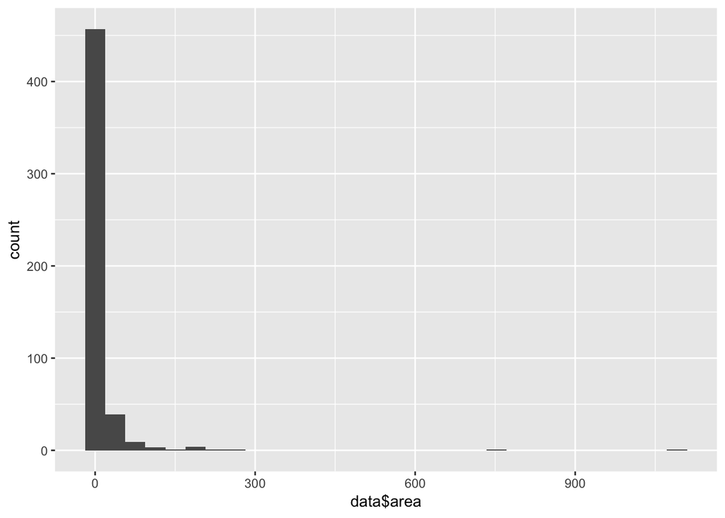

```r
ggplot(data, aes(data$area)) + geom_histogram()
```

We can see that the data is heavily skewed towards small forest fires. There are 247 entries with area = 0, for incidents where the resulting burned area was < $100 m^2$. A logarithmic transofrmation of area might be useful in this case, and we can add 1 to the target column first since $ln(0)$ approaches negative infinity.

## 2.3 Some Visualizations

```r
# describe(data)

# columns
names(data)
```

```
##  [1] "X"     "Y"     "month" "day"   "FFMC"  "DMC"   "DC"    "ISI"   "temp"  "RH"    "wind"  "rain"
## [13] "area"
```

```r
# numeric data
names(Filter(is.numeric, data))
```

```
##  [1] "X"    "Y"    "FFMC" "DMC"  "DC"   "ISI"  "temp" "RH"   "wind" "rain" "area"
```

```r
# factor data
names(Filter(is.factor, data))
```

```
## [1] "month" "day"
```

```r
# check NAs
sum(is.na(data))
```

```
## [1] 0
```

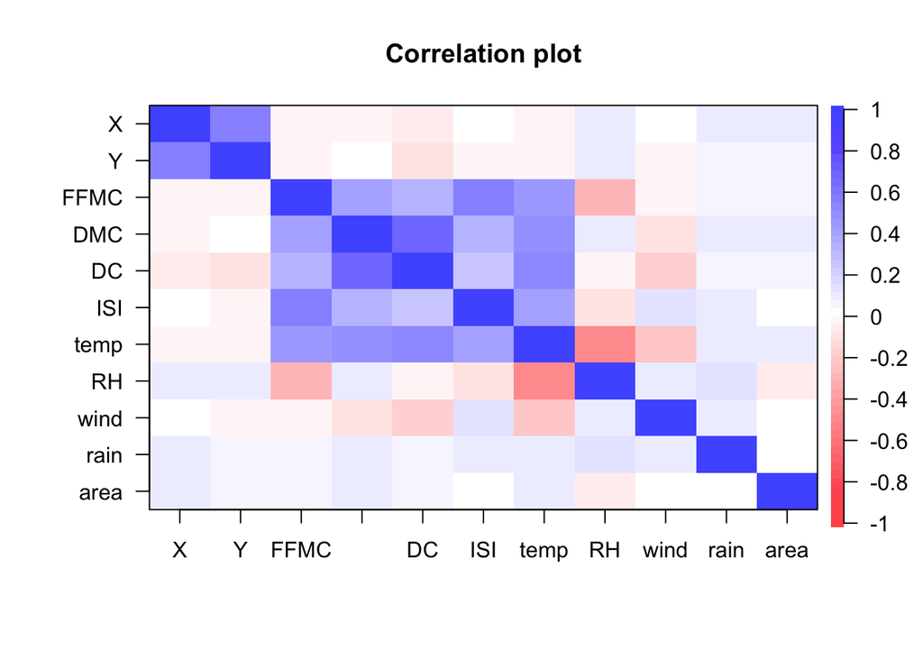

```r
# check correlation - there is some collinearity based on which we might drop features
corPlot(Filter(is.numeric, data))
```

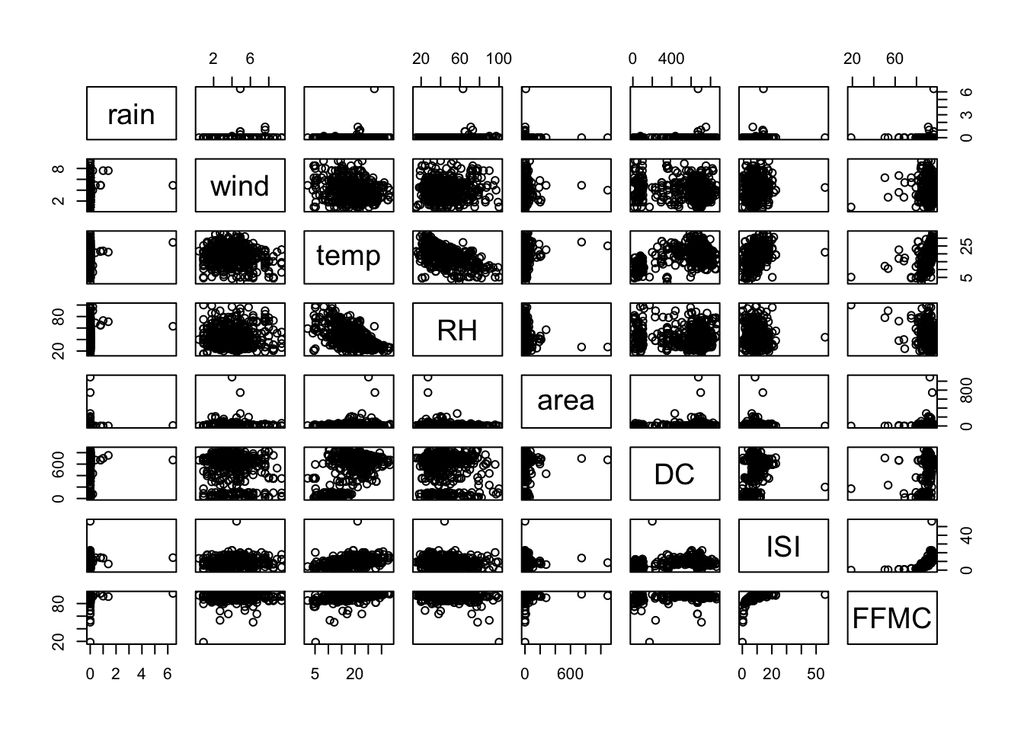

```r
# visualize relation between target and major predictors
pairs(dplyr::select(data, c("rain", "wind", "temp", "RH", "area", "DC", "ISI", "FFMC")))
```

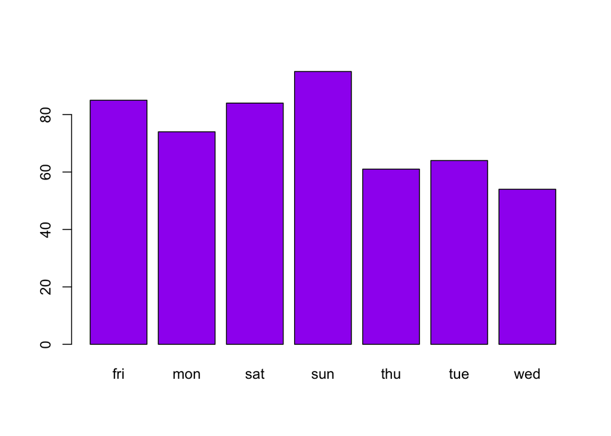

```r
# day/month wise incidents
plot(data$day, col = "purple")
```

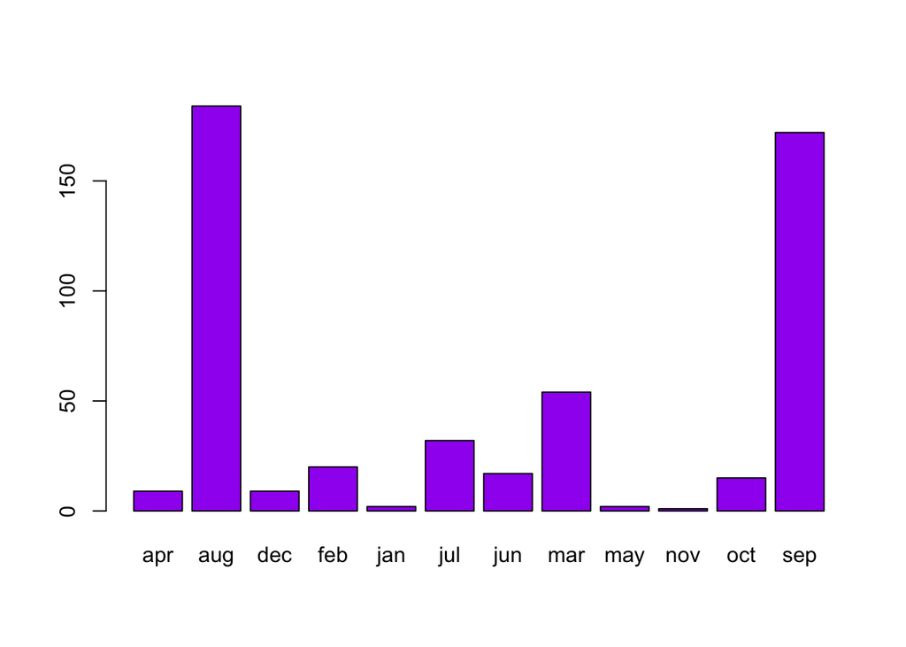

```r
plot(data$month, col = "purple")
```

There are more incidents on weekends - Friday/Sat/Sun, it might mean that campers vactioning might have caused/spotted fires.

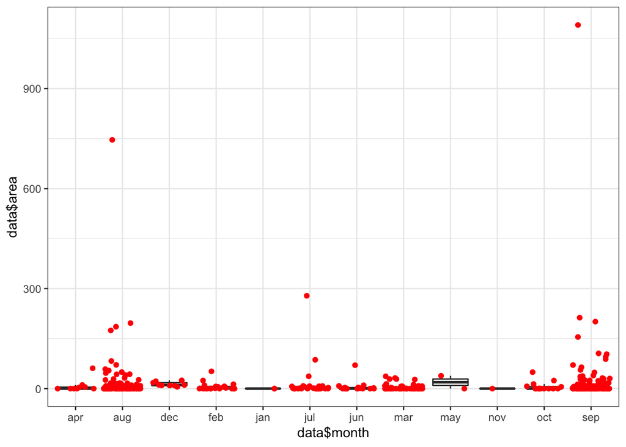

```r
# Day/Month wise area Burnt
ggplot(data, aes(x = data$month, data$area)) + geom_boxplot(outlier.shape = NA) + geom_jitter(col = "red") +
    theme_bw()
```

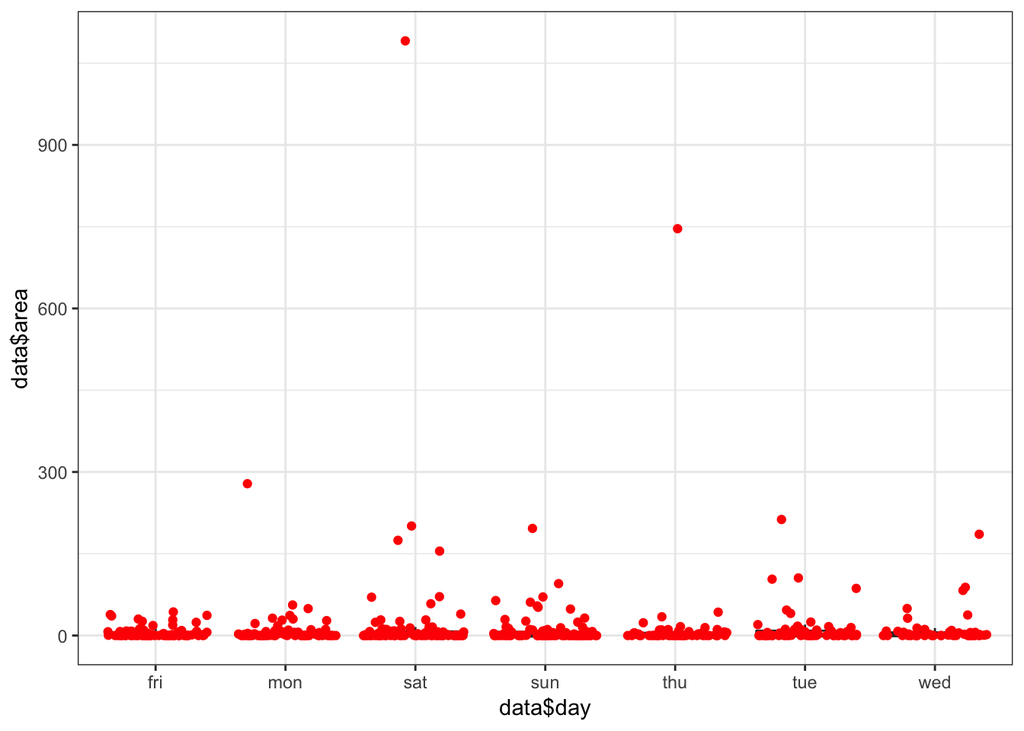

```r
ggplot(data, aes(x = data$day, data$area)) + geom_boxplot(outlier.shape = NA) + geom_jitter(col = "red") +
    theme_bw()
```

# 3 Data Preparation

## 3.1 Outlier Detection

We see from the boxplot below that there are some outliers that may skew our results. These are removed, so that we are predicting burned areas of smaller to medium forest fires. This is reasonable, since those are the more frequently encountered ones in real-life scenarios as well, and the ones for which resource prioritization may matter more. We are left with 501 observations after this.

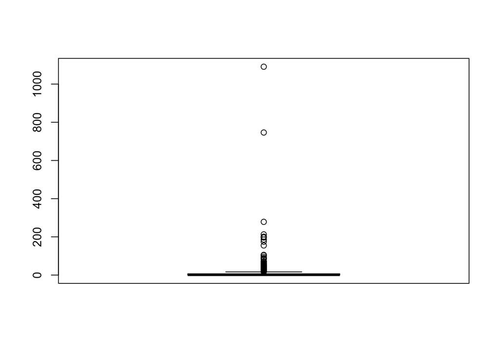

```r
boxplot(data$area)
```

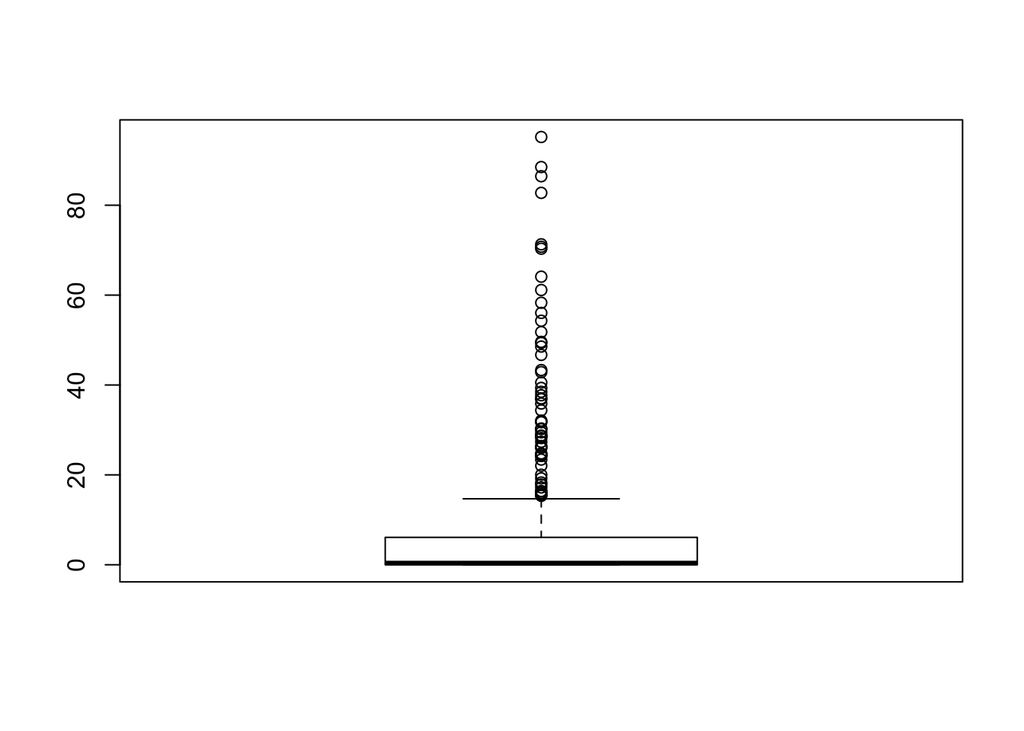

```r
outlier_values <- boxplot.stats(data$area)$out

# we decided to remove burnt areas more than 100 by doing this we remove only 11 major outliers from
# the data set and are keeping the rest
data = dplyr::filter(data, data$area < 100)
boxplot(data$area)
```

```r
# removing months with 1 or 2 records to avoid prediction issues
data <- data[!(data$month == "jan" | data$month == "nov" | data$month == "may"), ]
```

## 3.2 Feature Selection and Normalization

The ‘X’ and ‘Y’ attributes are coordinates in the 9x9 grid representing the area of Portugal’s Montesinho Park. These coordinates are specific to this situation, and wouldn’t generalize to prediction of burned area in other scenarios. These variables were also not found to be crucial to predicting the burned area.

For SVM and k-NN, we need to use normalized data on the 0-1 scale, since these algorithms depend on distance. So for consistency and model comparison we will use normalized data for all models.

```r
normalize_c = function(x) {
    return((x - min(x))/(max(x) - min(x)))
}

denormalize <- function(x, min_x, max_x) {
    return(x * (max_x - min_x) + min_x)
}

# Storing original data to data0
data0 <- dplyr::select(data, -c("X", "Y"))

# Xs - normalize all predictors
data_norm <- data %>% mutate_at(names(Filter(is.numeric, data)), normalize_c) %>% dplyr::select(-c(X,
    Y))

summary(data_norm)
```

```
##      month      day          FFMC             DMC               DC              ISI
##  aug    :180   fri:84   Min.   :0.0000   Min.   :0.0000   Min.   :0.0000   Min.   :0.0000
##  sep    :166   mon:73   1st Qu.:0.8712   1st Qu.:0.2330   1st Qu.:0.5092   1st Qu.:0.1095
##  mar    : 54   sat:78   Median :0.8996   Median :0.3666   Median :0.7697   Median :0.1436
##  jul    : 31   sun:93   Mean   :0.8827   Mean   :0.3763   Mean   :0.6360   Mean   :0.1563
##  feb    : 20   thu:60   3rd Qu.:0.9279   3rd Qu.:0.4846   3rd Qu.:0.8284   3rd Qu.:0.1903
##  jun    : 17   tue:60   Max.   :1.0000   Max.   :1.0000   Max.   :1.0000   Max.   :1.0000
##  (Other): 33   wed:53
##       temp              RH              wind             rain               area
##  Min.   :0.0000   Min.   :0.0000   Min.   :0.0000   Min.   :0.000000   Min.   :0.000000
##  1st Qu.:0.4277   1st Qu.:0.2143   1st Qu.:0.2556   1st Qu.:0.000000   1st Qu.:0.000000
##  Median :0.5498   Median :0.3214   Median :0.4000   Median :0.000000   Median :0.004518
##  Mean   :0.5373   Mean   :0.3474   Mean   :0.4037   Mean   :0.003493   Mean   :0.066128
##  3rd Qu.:0.6624   3rd Qu.:0.4524   3rd Qu.:0.5556   3rd Qu.:0.000000   3rd Qu.:0.064089
##  Max.   :1.0000   Max.   :1.0000   Max.   :1.0000   Max.   :1.000000   Max.   :1.000000
##
```

## 3.3 Train-Validation Split

Next, we will prepare the training and test dataset.

```r
set.seed(1234)
# split training and test data 80/20
train.index <- createDataPartition(data_norm$area, p = 0.8, list = FALSE)
test.index <- -train.index
```

Separating the data for GBM use:

```r
library(xgboost)
# convert data for xgboost - onehot encoding is automatically done
x.train <- model.matrix(area ~ ., data_norm[train.index, ])[, -11]
y.train <- data_norm[train.index, "area"]

dtrain <- xgb.DMatrix(data = x.train, label = y.train)

x.test <- model.matrix(area ~ ., data_norm[test.index, ])[, -11]
y.test <- data_norm[test.index, "area"]
```

# 4 Modelling

## 4.1 Elastic Net

We see that when using stepAIC, the temperature and wind features are selected.

```r
library(glmnetUtils)
library(MASS)
library(boot)

model_lm = glm(area ~ ., data = data_norm[train.index, ], family = "gaussian")
summary(model_lm)
```

```
##
## Call:
## glm(formula = area ~ ., family = "gaussian", data = data_norm[train.index,
##     ])
##
## Deviance Residuals:
##      Min        1Q    Median        3Q       Max
## -0.17163  -0.07293  -0.04129   0.00352   0.85906
##
## Coefficients:
##              Estimate Std. Error t value Pr(>|t|)
## (Intercept) -0.095793   0.111979  -0.855   0.3928
## monthaug    -0.008282   0.096468  -0.086   0.9316
## monthdec     0.111164   0.096168   1.156   0.2484
## monthfeb     0.002012   0.065437   0.031   0.9755
## monthjul    -0.009456   0.085153  -0.111   0.9116
## monthjun    -0.026743   0.080933  -0.330   0.7413
## monthmar    -0.056564   0.059245  -0.955   0.3403
## monthoct     0.092775   0.115178   0.805   0.4210
## monthsep     0.065539   0.108211   0.606   0.5451
## daymon       0.027640   0.028162   0.981   0.3270
## daysat       0.016029   0.026693   0.600   0.5485
## daysun       0.034319   0.025901   1.325   0.1860
## daythu       0.007403   0.029465   0.251   0.8018
## daytue       0.019790   0.028143   0.703   0.4824
## daywed       0.048942   0.031164   1.570   0.1171
## FFMC         0.083584   0.099711   0.838   0.4024
## DMC          0.112136   0.066401   1.689   0.0921 .
## DC          -0.191496   0.127406  -1.503   0.1337
## ISI         -0.119917   0.123485  -0.971   0.3321
## temp         0.172024   0.086470   1.989   0.0474 *
## RH           0.054666   0.065218   0.838   0.4024
## wind         0.100741   0.042913   2.348   0.0194 *
## rain        -0.045492   0.150066  -0.303   0.7619
## ---
## Signif. codes:  0 '***' 0.001 '**' 0.01 '*' 0.05 '.' 0.1 ' ' 1
##
## (Dispersion parameter for gaussian family taken to be 0.02239154)
##
##     Null deviance: 8.9728  on 401  degrees of freedom
## Residual deviance: 8.4864  on 379  degrees of freedom
## AIC: -362.08
##
## Number of Fisher Scoring iterations: 2
```

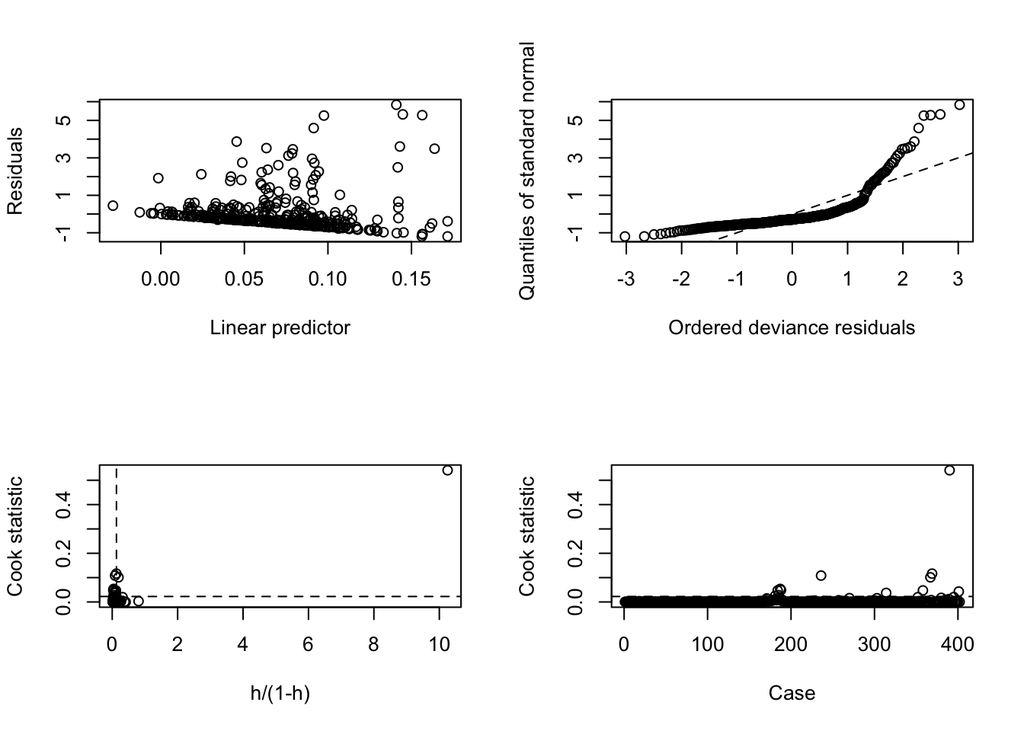

```r
glm.diag.plots(model_lm)
```

```r
# denormalize prediction
test_pred_area_lm <- denormalize(predict(model_lm, data_norm[test.index, ]), min(data$area), max(data$area))
rmse(test_pred_area_lm, data[test.index, "area"])
```

```
## [1] 11.96472
```

```r
############## STEP AIC ##
model_step <- stepAIC(model_lm, direction = "both")
```

```
## Start:  AIC=-362.08
## area ~ month + day + FFMC + DMC + DC + ISI + temp + RH + wind +
##     rain
##
##         Df Deviance     AIC
## - day    6   8.5689 -370.20
## - month  8   8.7310 -366.66
## - rain   1   8.4885 -363.99
## - RH     1   8.5021 -363.34
## - FFMC   1   8.5021 -363.34
## - ISI    1   8.5075 -363.09
## <none>       8.4864 -362.08
## - DC     1   8.5370 -361.70
## - DMC    1   8.5503 -361.07
## - temp   1   8.5750 -359.91
## - wind   1   8.6098 -358.28
##
## Step:  AIC=-370.2
## area ~ month + FFMC + DMC + DC + ISI + temp + RH + wind + rain
##
##         Df Deviance     AIC
## - month  8   8.8155 -374.79
## - rain   1   8.5722 -372.04
## - FFMC   1   8.5838 -371.50
## - ISI    1   8.5879 -371.30
## - RH     1   8.5941 -371.01
## <none>       8.5689 -370.20
## - DC     1   8.6179 -369.90
## - DMC    1   8.6233 -369.65
## - wind   1   8.6835 -366.86
## - temp   1   8.6835 -366.85
## + day    6   8.4864 -362.08
##
## Step:  AIC=-374.79
## area ~ FFMC + DMC + DC + ISI + temp + RH + wind + rain
##
##         Df Deviance     AIC
## - DMC    1   8.8156 -376.79
## - RH     1   8.8168 -376.73
## - rain   1   8.8173 -376.71
```

[output cut: 89 more lines]

```
## Step:  AIC=-384.85
## area ~ temp + wind
##
##         Df Deviance     AIC
## <none>       8.8581 -384.85
## - temp   1   8.9112 -384.45
## + ISI    1   8.8334 -383.97
## + DC     1   8.8544 -383.02
## - wind   1   8.9446 -382.95
## + rain   1   8.8567 -382.91
## + DMC    1   8.8574 -382.89
## + RH     1   8.8577 -382.87
## + FFMC   1   8.8580 -382.86
## + day    6   8.7771 -376.54
## + month  8   8.6938 -376.38
```

```r
test_pred_area_step <- denormalize(predict(model_step, newdata = data_norm[test.index, ]), min(data$area),
    max(data$area))
rmse(test_pred_area_step, data[test.index, "area"])
```

```
## [1] 11.93274
```

```r
########### RIDGE ##
model_ridge = cv.glmnet(area ~ ., data = data_norm[train.index, ], nfolds = 10, use.model.frame = T,
    alpha = 0)

lam_ridge = model_ridge$lambda.min

# test set predictions
test_pred_area_ridge = denormalize(predict(model_ridge, s = lam_ridge, data_norm[test.index, ], exact = TRUE),
    min(data$area), max(data$area))
ridge.rmse <- rmse(test_pred_area_ridge, data[test.index, "area"])

########### LASSO ##

model_lasso = cv.glmnet(area ~ ., data = data_norm[train.index, ], nfolds = 10, use.model.frame = T,
    alpha = 1)

lam_lasso = model_lasso$lambda.min


# test set predictions
test_pred_area_lasso = denormalize(predict(model_lasso, s = lam_lasso, data_norm[test.index, ], exact = TRUE),
    min(data$area), max(data$area))
rmse(test_pred_area_lasso, data[test.index, "area"])
```

```
## [1] 11.89975
```

## 4.2 k-Nearest Neighbours Regression

```r
library(onehot)
library(class)
library(FNN)
library(Metrics)

# Encode factors to dummies for KNN
data_norm$month = as.factor(data_norm$month)
data_norm$day = as.factor(data_norm$day)

encoder = onehot(data_norm, max_levels = 100)
knn_data = as.data.frame(predict(encoder, data_norm))

# Separating train and test for KNN
train_knn = knn_data[train.index, ]
test_knn = knn_data[-train.index, ]

# Finding out optimal K
ks = 1:30
mse.train = numeric(length = length(ks))
mse.test = numeric(length = length(ks))

for (i in seq(along = ks)) {
    model.train = knn.reg(train_knn, train_knn, train_knn$area, k = ks[i])
    model.test = knn.reg(train_knn, test_knn, train_knn$area, k = ks[i])
    mse.train[i] = mean((train_knn$area - model.train$pred)^2)
    mse.test[i] = mean((test_knn$area - model.test$pred)^2)
}

k.opt = ks[which.min(mse.test)]

# KNN regression
knn_pred = knn.reg(train_knn, test_knn, train_knn$area, k = k.opt)

knn_rmse = rmse(denormalize(knn_pred$pred, min(data$area), max(data$area)), data[test.index, "area"])
knn_rmse  # 7.45
```

```
## [1] 7.45965
```

## 4.3 Support Vector Machines

For both k-NN and SVM we first tried predicting log_area, which turned out yielding generally low accuracies. We believe this is due to k-NN and SVM being distance depended algorithms, and so ran the models without logarithmic transformation in the end.

```r
library(e1071)

# Linear kernel
svm_linear = svm(area ~ ., data = data_norm[train.index, ], kernel = "linear", cost = 32, gamma = 0.03846154,
    epsilon = 0.4)
pred.linear = predict(svm_linear, data_norm[test.index, ])

pred.linear.denormalized = denormalize(pred.linear, min(data$area), max(data$area))
svm_lin_rmse = rmse(pred.linear.denormalized, data[test.index, "area"])
svm_lin_rmse
```

```
## [1] 11.7473
```

```r
# RBF kernel
svm_rbf = svm(area ~ ., data = data_norm[train.index, ], kernel = "radial", cost = 4, gamma = 0.03846154,
    epsilon = 0.4)
pred.rbf = predict(svm_rbf, data_norm[test.index, ])

pred.rbf.denormalized = denormalize(pred.rbf, min(data$area), max(data$area))
svm_rbf_rmse = rmse(pred.rbf.denormalized, data[test.index, "area"])
svm_rbf_rmse
```

```
## [1] 11.88896
```

## 4.4 Random Forest

For random forest, too, though using the log transformed area was thought to show better results, there wasn’t much change to the performance (test RMSE). This could be because the extreme outliers were anyway removed, leading to more symmetry in the data without the transform.

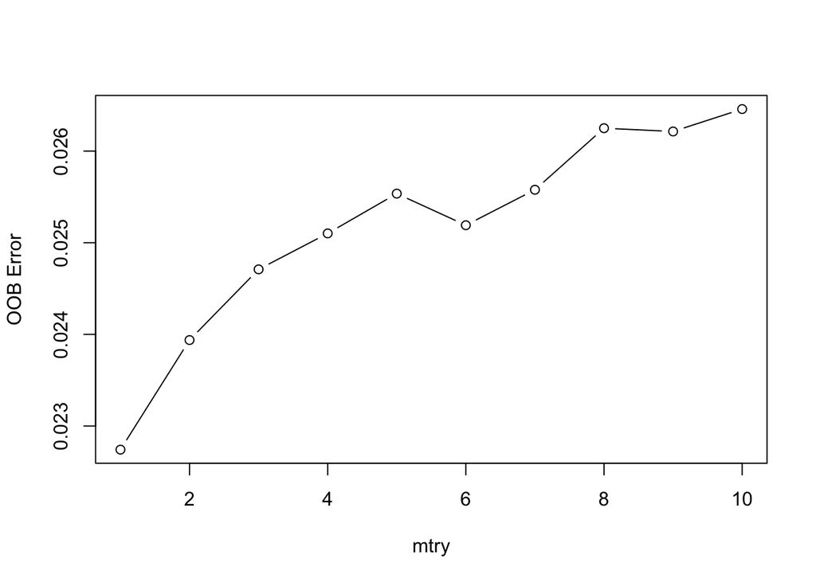

```r
library("randomForest")

# tune random forest (mtry) manually
mse.rfs <- rep(0, 10)  # repeat '0' 10 times

for (m in 1:10) {
    set.seed(12345)
    rf <- randomForest(area ~ ., data = data_norm, subset = train.index, ntree = 501, mtry = m)
    mse.rfs[m] <- rf$mse[501]
}

plot(1:10, mse.rfs, type = "b", xlab = "mtry", ylab = "OOB Error")
```

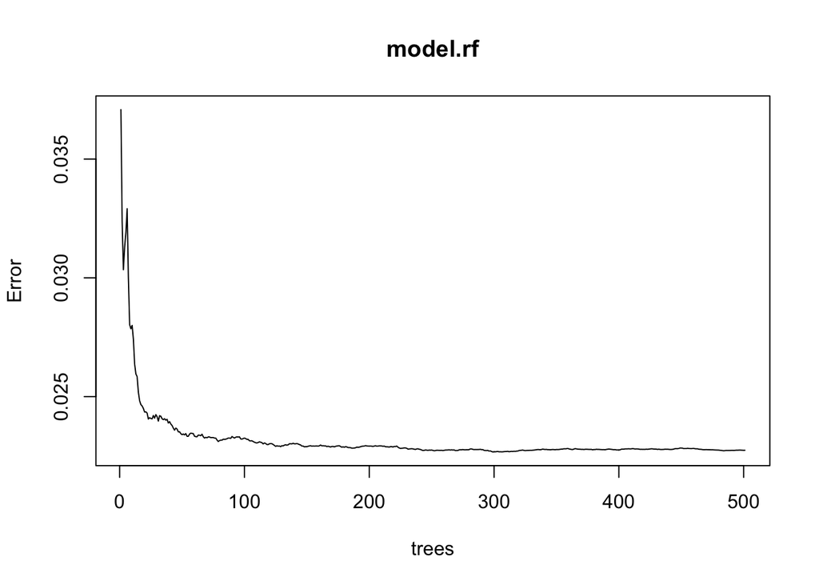

```r
# fit a random forest model
set.seed(12345)
model.rf <- randomForest(area ~ ., data = data_norm, subset = train.index, ntree = 501, mtry = 1)
plot(model.rf)
```

```r
# predict on train set
pred.rf.train <- predict(model.rf, newdata = data_norm[train.index, ])

# predict on test set
pred.rf <- predict(model.rf, newdata = data_norm[test.index, ])

# inverse log - 1
pred.rf.train <- denormalize(pred.rf.train, min(data$area), max(data$area))
pred.rf <- denormalize(pred.rf, min(data$area), max(data$area))

# rmse in train and test data
rmse(pred.rf.train, data[train.index, "area"])
```

```
## [1] 10.18163
```

```r
rf.rmse <- rmse(pred.rf, data[test.index, "area"])
```

### 4.4.1 RF Variable Importance Plot

We see that temp, RH (relative humidity), and some of the fire weather indices - DC, DMC and ISI are found to be important in prediction of the burned area. This is consistent with the findings from [1].

```r
# variable importance
importance(model.rf)
```

```
##       IncNodePurity
## month    0.37617528
## day      0.46899051
## FFMC     0.51435188
## DMC      0.56059735
## DC       0.52092786
## ISI      0.53019702
## temp     0.67638278
## RH       0.52784552
## wind     0.45478569
## rain     0.01332297
```

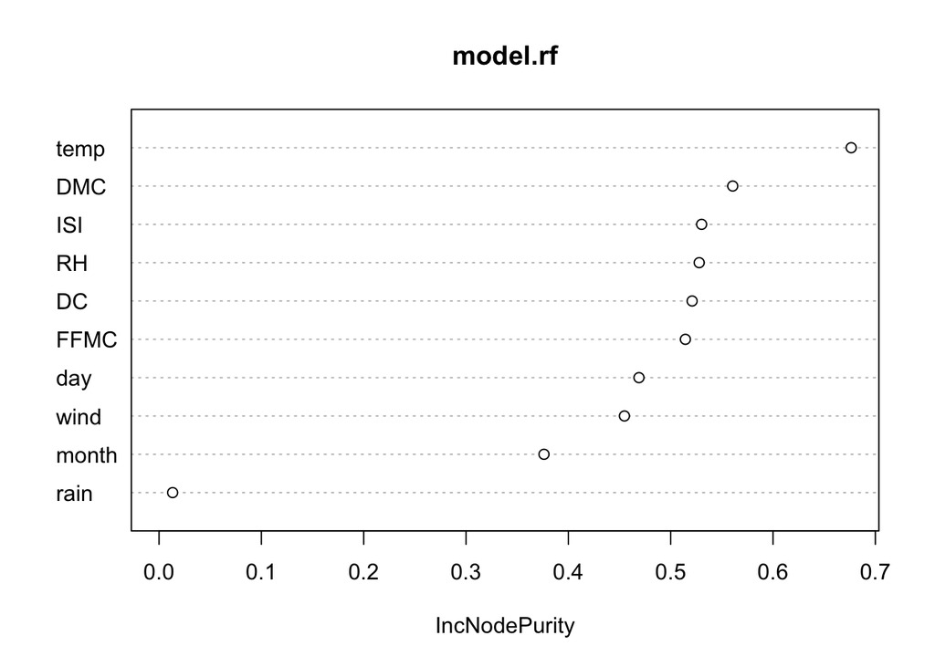

```r
varImpPlot(model.rf)
```

## 4.5 XGBoost

```r
# fit a boosting model with optimal parameters - from running 9-xgboost_tuning.R with dtrain as input
max_depth.opt <- 2
eta.opt <- 0.01
subsample.opt <- 1
colsample.opt <- 1
nrounds.opt <- 260

set.seed(12345)
model.xgb <- xgboost(data = dtrain, objective = "reg:linear", nrounds = nrounds.opt, max_depth = max_depth.opt,
    eta = eta.opt, subsample = subsample.opt, colsample_bytree = colsample.opt, verbose = 0)

# train predict
pred.xgb.train <- predict(model.xgb, x.train)

# predict
pred.xgb <- predict(model.xgb, x.test)

# inverse log
pred.xgb <- denormalize(pred.xgb, min(data$area), max(data$area))
pred.xgb.train <- denormalize(pred.xgb.train, min(data$area), max(data$area))

# rmse
rmse(pred.xgb.train, data[train.index, "area"])
```

```
## [1] 13.27126
```

```r
xgb.rmse <- rmse(pred.xgb, data[test.index, "area"])
```

### 4.5.1 XGBoost Variable Importance Plot

For this model, too, temp, RH and DC are important. Additionally, wind and FFMC are found to be important in prediction of the burned area. This is consistent with the feature selection from stepAIC and similar to the variable importance plot of our random forest model above.

```r
importance_matrix <- xgb.importance(model = model.xgb, feature_names = colnames(x.train))
importance_matrix
```

| Feature | Gain | Cover | Frequency |
| --- | --- | --- | --- |
| temp | 0.27882802 | 0.443547500 | 0.35644938 |
| DC | 0.16082080 | 0.047454075 | 0.08460472 |
| wind | 0.16006244 | 0.252979936 | 0.22330097 |
| FFMC | 0.13788706 | 0.013494050 | 0.03606103 |
| ISI | 0.11404723 | 0.153899158 | 0.12343967 |
| RH | 0.06053280 | 0.066407951 | 0.08737864 |
| monthsep | 0.02485132 | 0.001961901 | 0.01386963 |
| daytue | 0.02316561 | 0.001555165 | 0.03467406 |
| daywed | 0.02246260 | 0.001071868 | 0.02219140 |
| DMC | 0.01734212 | 0.017628397 | 0.01803051 |

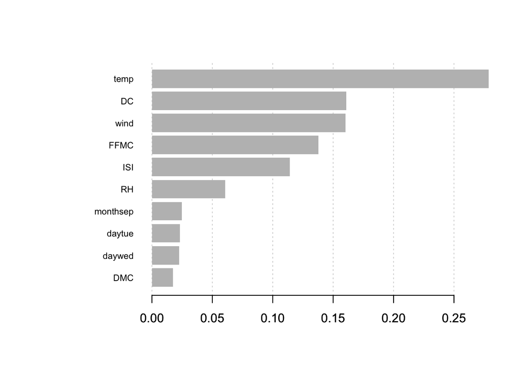

```r
xgb.plot.importance(importance_matrix = importance_matrix)
```

## 4.6 Ensemble

Using test RMSE as our performance metric, we observe that both k-NN and SVM (linear kernel) give us good results as compared to the other models. Hence, we stack the above two models. We find that the combination of these also gives a similar result.

```r
set.seed(17)
folds <- createFolds(data_norm[train.index, "area"], 5)

control <- trainControl(method = "repeatedcv", number = 5, repeats = 2, index = folds, search = "grid",
    savePredictions = "final")

algos <- c("knn", "svmLinear")

models <- caretList(area ~ ., data = data_norm[train.index, ], metric = "RMSE", trControl = control,
    methodList = algos)

models_perf <- resamples(models)
modelCor(models_perf)
```

```
##                  knn  svmLinear
## knn        1.0000000 -0.4118291
## svmLinear -0.4118291  1.0000000
```

```r
stack_control <- trainControl(method = "repeatedcv", number = 2, repeats = 5)

stack_lm <- caretStack(models, method = "lm", trControl = stack_control)

pred_stack <- predict(stack_lm, data_norm[test.index, ])

## RMSE of Stacking Model
pred_stack_denormalized = denormalize(pred_stack, min(data$area), max(data$area))
stack_accuracy <- rmse(pred_stack_denormalized, data[test.index, "area"])
stack_accuracy  # 13.89
```

```
## [1] 12.0204
```

```r
## Manual Stacking of KNN, SVM Linear
knn_pred_train = knn.reg(train_knn, train_knn, train_knn$area, k = k.opt)
pred.linear.train = predict(svm_linear, data_norm[train.index, ])


stack_train_data <- cbind.data.frame(knn_pred_train$pred, pred.linear.train, data_norm[train.index, "area"])
stack_test_data <- cbind.data.frame(knn_pred$pred, pred.linear, data_norm[test.index, "area"])

names(stack_train_data) <- c("KNN", "SVMLinear", "area")
names(stack_test_data) <- c("KNN", "SVMLinear", "area")

manual_stack_model <- glm(area ~ ., data = stack_train_data)

## Predicting test on the Manual Stack

pred_stack_manual <- predict(manual_stack_model, stack_test_data)

## RMSE of Manual Stack Model
pred_stack_manual_denormalized = denormalize(pred_stack_manual, min(data$area), max(data$area))
manual_stack_rmse = rmse(pred_stack_manual_denormalized, data[test.index, "area"])
manual_stack_rmse
```

```
## [1] 7.45965
```

# 5 Results and Model Comparison

```r
library(knitr)

models <- c("Ridge", "k-NN", "SVM Linear", "RF", "XGBoost", "Manual Stacking")
rmses <- c(ridge.rmse, knn_rmse, svm_lin_rmse, rf.rmse, xgb.rmse, manual_stack_rmse)

final_results <- data.frame(Model = models, `Test RMSE` = rmses)

kable(final_results, caption = "Model Comparison")
```

Model Comparison

| Model | Test.RMSE |
| --- | --- |
| Ridge | 11.89975 |
| k-NN | 7.45965 |
| SVM Linear | 11.74730 |
| RF | 11.97010 |
| XGBoost | 12.92295 |
| Manual Stacking | 7.45965 |

# 6 Conclusion and Discussion

- Due to the small size of the dataset and the skew towards small forest fires, the results may not be as accurate as possible.
- One way to deal with this is by labeling the datapoints by their severity (small, medium, big, or small/others) and considering it as a classification problem. This would still serve the purpose of prioritizing resource allocation. Sampling techniques like over- or under-sampling could also then be applied to the training set.
- For pro-active measures, weather forecasts could be used instead to predict the occurrence and burned area of forest fires in the future.
- RMSE is more sensitive to outliers. Using another metric, like Mean Absolute Deviance (MAD) may be better for this dataset and problem.
- Though taking log transformations may give better results for regression problems, it didn’t have much impact in this case - possibly because we removed some of the extreme outliers first.

# 7 References

1. Cortez, P., & Morais, A. D. J. R. (2007). A data mining approach to predict forest fires using meteorological data. Available at: http://www3.dsi.uminho.pt/pcortez/fires.pdf
2. Government of Canada. (2017, September 17). Canadian Wildland Fire Information System. Retrieved November 29, 2018 from http://cwfis.cfs.nrcan.gc.ca/background/summary/fwi
3. Insurance Journal. (2018, November 27). Report Puts Losses from California Wildfires at $15B to $19B. Retrieved November 29, 2018, from https://www.insurancejournal.com/news/west/2018/11/27/510160.htm
4. Vidal, J. (2018, July 28). Fire, Fire Everywhere: The 2018 Global Wildfire Season Is Already Disastrous. Retrieved from https://www.huffingtonpost.in/entry/fire-fire-everywhere-the-2018-global-wildfire-season-is-already-disastrous_us_5b5a1271e4b0de86f494ed28
5. Ozbayoglu, A. M., & Bozer, R. (2012). Estimation of the burned area in forest fires using computational intelligence techniques. Procedia Computer Science, 12, 282-287.